# Efficient Fused Lasso

### Fused LASSO Motivation

We are following the implementation of trend filtering from Ramdas and Tibshirani (2016) which recommends splitting the ADMM task into a least squares step and a fused LASSO step, with the motivation being that a very fast algorithm for the fused LASSO was developed in Johnson (2013). Additionally, they demonstrate that there are statistical reasons to use the fused LASSO.

### Source Code

To implement this, we use a `C++` implementation of the dynamic programming algorithm written for CMU’s convex optimization class. The `C++` code and the loading routine are both directly imported from [this FTP](https://www.stat.cmu.edu/~ryantibs/convexopt-F13/homeworks/).

```r
setwd("C:/Users/drain/Box Sync/USC_Stuff/Featureless_Flowmix/fused_lasso_C")
dyn.load("tf_dp_ryan_orig.dll")

prox = function(z, lam) {
  if (!is.loaded("prox_dp_R")) {
    dyn.load("prox_R.so")
  }

  o = .C("prox_dp_R",
         n=as.integer(length(z)),
         z=as.double(z),
         lam=as.double(lam),
         beta=as.double(numeric(length(z))),
         dup=FALSE)

  return(o$beta)
}
```

Note that the `prox` routine does actually work in practice,

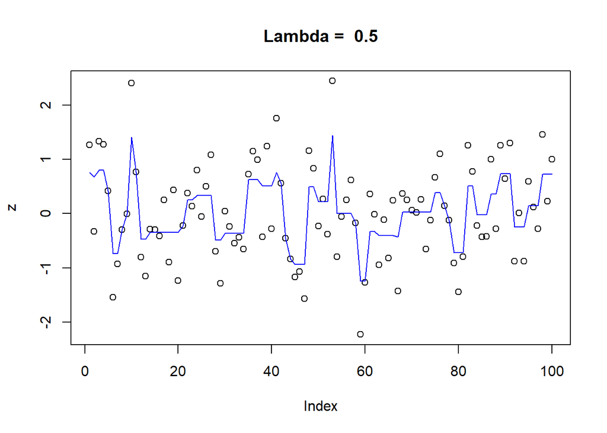

```r
set.seed(0)
z <- rnorm(100)
lam <- 0.5


out <- prox(z, lam)
plot(z, main = paste("Lambda = ", lam))
lines(out, col = 'blue')
```

Increasing the penalty (predictably) smoothes the fit:

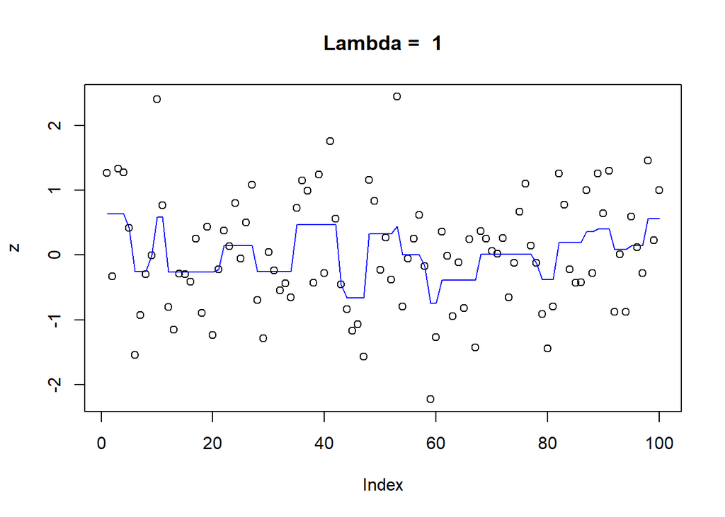

```r
out <- prox(z, 2*lam)
plot(z, main = paste("Lambda = ", 2*lam))
lines(out, col = 'blue')
```

### Performance

Now, using the `microbenchmark` function to evaluate performance by repeating this procedure 1000 times:

```r
library(microbenchmark)

run_prox <- function(n = 1e3){
  z <- rnorm(n)
  lam <- 0.5
  out <- lapply(1:1000, FUN = function(x) prox(z, lam))
}

microbenchmark(run_prox)
```

```
## Unit: nanoseconds
##      expr min lq mean median uq  max neval
##  run_prox   0  0   17      0  0 1700   100
```

This seems quite fast to me (though I will admit I don’t have much experience in benchmarking).

### Applying to our ADMM algorithm

The ADMM procedure for trend filtering recommended by Ramdas and Tibshirani (2016) does not involve performing the fused LASSO on the original data, but rather on a modified version. The problem we solve within each ADMM loop is actually
$$\min_{w_j} \|\xi_j - w_j \|^2 + \frac{2\lambda}{\rho} \| D^{(1)}w_j \|_1$$

where $\rho$ is an ADMM parameter, $w_j$ is an ADMM variable correpsonding to dimension $j$ of the cytogram, and $D^{(1)}$ is the first degree differencing matrix, and $\xi_j$ is an internal variable that is calculated at M step of the algorithm. Thus, a complete $w$ pass in the ADMM algorithm would look something like the function below:

```r
w_update_fused <- function(l, mu, uw, rho, lambda){

  TT <- length(mu)
  D <- gen_diff_mat(n = TT, l = l)

  # modified lambda for fused lasso routine
  mod_lam <- lambda*2/rho

  # generating pseudo response xi
  xi <- D %*% mu + 1/rho * uw

  # running the fused LASSO
  fit <- prox(z = xi, lam = mod_lam)

  return(fit)
}
```

A quick (but somewhat nonsensical example):

```r
set.seed(100)
l = 2 # degree of differencing
lambda = 0.01 # penalty term
rho = 0.22 # ADMM parameter
mu <- rnorm(100, mean = 0, sd = 0.25) # current mean estimates along dimension j
uw <- rnorm(100-l, mean = 0, sd = 0.05) # nonsensical ADMM variable estimates

w_update_fused(l = l, mu = mu, uw = uw, rho = rho, lambda = lambda)
```

```
##  [1] -0.195798250  0.422017927 -0.358685073  0.252612551 -0.425063925
##  [6]  0.276389242 -0.703669175  0.256738568  0.256738568  0.004856516
## [11]  0.004856516  0.185891459 -0.347332460 -0.208880416 -0.126932022
## [16]  0.162172479 -0.167886148  0.922292251 -1.380065592  1.172904960
## [21] -0.420088243  0.167931658 -0.475703798  0.403436178 -0.333802533
## [26]  0.008518469 -0.466730827  0.745519267 -0.360651015  0.432555375
## [31] -0.849083703  0.139583038  0.139583038  0.139583038  0.139583038
## [36]  0.063620459  0.063620459 -0.076875813 -0.076875813  0.566011687
## [41] -1.082208650  0.727520569 -0.668738915  0.715609194 -0.923872400
## [46]  0.407125314 -0.657027204 -0.279085079  0.751915342 -0.468474312
## [51]  0.855587471  0.326080702 -1.294258650  1.668126266 -1.169227368
## [56]  1.142309554 -0.760761957 -0.466617618  0.577453227 -0.031689887
## [61] -0.031689887  0.649318544 -1.211712698  0.475554144  0.475554144
## [66] -0.408146444 -0.055432869 -0.055432869  0.005205643 -0.139485424
## [71]  0.497452019  0.591208799 -1.469269400  1.330339541 -0.624391166
## [76] -0.031288489 -0.073591311 -0.858056082  1.619954741 -0.336859222
## [81] -0.336859222  0.311435077  0.653031856 -0.814276248  0.269582608
## [86]  0.217639776  0.056023425 -0.570461909  0.097622323  0.285872326
## [91] -0.947808489  0.413944531  0.413944531  0.413944531 -0.950976727
## [96]  0.851505181 -0.169657615  0.345108570
```

This is also quite fast (I hope!).

### References

Johnson, Nicholas A. 2013. “A Dynamic Programming Algorithm for the Fused Lasso and l 0-Segmentation.” *Journal of Computational and Graphical Statistics* 22 (2): 246–60.

Ramdas, Aaditya, and Ryan J Tibshirani. 2016. “Fast and Flexible Admm Algorithms for Trend Filtering.” *Journal of Computational and Graphical Statistics* 25 (3): 839–58.